# Revision

- Show All Code
- Hide All Code
- View Source

```r
# Force UTF-8 locale so em-dashes and other non-ASCII characters render correctly
suppressWarnings(Sys.setlocale("LC_ALL", "en_US.UTF-8"))
```

```
[1] "en_US.UTF-8/en_US.UTF-8/en_US.UTF-8/C/en_US.UTF-8/C"
```

```r
options(encoding = "UTF-8")

library(tidyverse)
library(readxl)
library(knitr)
library(tableone)
library(gtsummary)
library(survival)
library(tidycmprsk)
library(ggsurvfit)

knitr::opts_chunk$set(echo = TRUE, message = FALSE, warning = FALSE)

data_dir <- "data"
all <- read_excel(file.path(data_dir, "All_edited_new_12142022.xlsx"))

site_files <- c("Baylor0913", "Indiana0913", "Jacksonville0913", "Kentukey0913",
                "MCW0913", "MGH0913", "Michigan0913", "Oschner0913",
                "Rochester0913", "USC0913", "Yale0913")

read_site <- function(name) {
  df <- read_excel(file.path(data_dir, paste0(name, ".xlsx")))
  if (name == "USC0913") df <- df %>% mutate(rrt_crrt = NA, days_icu = NA, cpr_given = NA)
  df %>% select(study_id, race, rrt_crrt, days_icu, cpr_given)
}
race_added <- bind_rows(lapply(site_files, read_site))
all <- merge(all, race_added, by = "study_id", all.x = TRUE)

all <- all %>%
  mutate(
    type_of_aki = case_when(
      final_type_of_aki == 1 ~ "Prerenal",
      final_type_of_aki == 2 ~ "HRS-AKI",
      final_type_of_aki == 3 ~ "ATN",
      final_type_of_aki == 4 ~ "Other",
      final_type_of_aki == 5 ~ "Unable to diagnosis"),
    etiology_cirrhosis = case_when(
      etiology_cirrhosis == 1 ~ "Alcohol",
      etiology_cirrhosis == 2 ~ "Hepatitis C",
      etiology_cirrhosis == 3 ~ "MASLD",
      etiology_cirrhosis == 5 ~ "Multifactorial",
      etiology_cirrhosis %in% c(4, 6, 7) ~ "Other"),
    race_cat_4 = case_when(
      ethnicity == 2 & race == 5 ~ "NHW",
      ethnicity == 1 & race == 5 ~ "HW",
      ethnicity %in% c(1, 2) & race == 3 ~ "Black",
      ethnicity %in% c(1, 2) & race %in% c(1, 2, 4, 6) ~ "NWNB"),
    race = case_when(
      race == 1 ~ "American Indian or Alaska Native",
      race == 2 ~ "Asian",
      race == 3 ~ "Black or African American",
      race == 4 ~ "Native Hawaiian or Other Pacific Islander",
      race == 5 ~ "White",
      race == 6 ~ "Other",
      race == 7 ~ "Unknown"),
    ethnicity = ifelse(ethnicity == 1, "Hispanic",
                ifelse(ethnicity == 2, "Non-Hispanic", "Unknown")),
    female = ifelse(sex == 2, 1, 0)
  )

calculate_meld3 <- function(female, bilirubin, sodium, inr, creatinine, albumin) {
  if (anyNA(c(female, bilirubin, sodium, inr, creatinine, albumin)) ||
      any(c(bilirubin, sodium, inr, creatinine, albumin) <= 0)) return(NA)
  1.33 * female + 4.56 * log(bilirubin) +
    0.82 * (137 - sodium) - 0.24 * (137 - sodium) * log(bilirubin) +
    9.09 * log(inr) + 11.14 * log(creatinine) +
    1.85 * (3.5 - albumin) - 1.83 * (3.5 - albumin) * log(creatinine) + 6
}

all <- all %>%
  mutate(meld_3 = mapply(calculate_meld3,
                         female, tb_admit, na_admit, inr_admit,
                         creatinine_admission, alb_admit))

n_total <- nrow(all)

step1 <- all %>% filter(race != "Unknown")
n1 <- nrow(step1)

step2 <- step1 %>% filter(ethnicity != "Unknown")
n2 <- nrow(step2)

step3 <- step2 %>%
  mutate(MELD_Na_baseline = replace_na(MELD_Na_baseline, median(MELD_Na_baseline, na.rm = TRUE))) %>%
  filter(MELD_Na_baseline >= 0)
n3 <- nrow(step3)

step4 <- step3 %>% filter(!is.na(meld_3))
n4 <- nrow(step4)

adjuster_vars <- c("age_admission", "etiology_cirrhosis", "hcc_admission",
                    "diabetes", "cad", "ckd", "htn", "site")
comorb_detail <- sapply(adjuster_vars, function(v) sum(is.na(step4[[v]])))

master <- step4 %>%
  filter(if_all(all_of(adjuster_vars), ~ !is.na(.)))
n5 <- nrow(master)

cat_var <- c("sex", "race_cat_4", "etiology_cirrhosis", "hcc_admission",
             "diabetes", "cad", "ckd", "htn", "site",
             "ascites_admission", "encephalopathy_admission",
             "type_of_aki", "aclf_grade", "status_90days")
for (v in intersect(cat_var, names(master))) master[[v]] <- as.factor(master[[v]])

master$race_cat_4 <- relevel(master$race_cat_4, ref = "NHW")
master$etiology_cirrhosis <- relevel(master$etiology_cirrhosis, ref = "Alcohol")
master$status_90days <- factor(master$status_90days)

master <- master %>%
  mutate(
    age_10 = age_admission / 10,
    meld_3_5 = meld_3 / 5,
    death_status_90days = ifelse(status_90days == 1, 1, 0)
  )

master_hrs <- master %>% filter(type_of_aki == "HRS-AKI")
```

## Exclusion Cascade

```r
comorb_nonzero <- comorb_detail[comorb_detail > 0]
comorb_note <- if (length(comorb_nonzero) > 0) {
  paste0(" (", paste(names(comorb_nonzero), comorb_nonzero, sep = " ", collapse = ", "), ")")
} else ""

exclusion_df <- tibble(
  Step = c(
    "Original HARMONY cohort",
    "  Excluded: Race unknown or not reported",
    "Remaining after race exclusion",
    "  Excluded: Ethnicity unknown or not reported",
    "Remaining after ethnicity exclusion",
    "  Excluded: MELD_Na_baseline < 0",
    "Remaining after MELD_Na_baseline filter",
    "  Excluded: Any element(s) of MELD 3.0 missing or non-positive",
    "Remaining after MELD 3.0 exclusion",
    paste0("  Excluded: Missing baseline covariates", comorb_note),
    "**Final cohort for analysis**",
    "  of which HRS-AKI sub-cohort"
  ),
  N = c(
    n_total,
    n_total - n1,
    n1,
    n1 - n2,
    n2,
    n2 - n3,
    n3,
    n3 - n4,
    n4,
    n4 - n5,
    n5,
    nrow(master_hrs)
  )
)

check_sum <- (n_total - n1) + (n1 - n2) + (n2 - n3) + (n3 - n4) + (n4 - n5)

kable(exclusion_df, caption = paste0(
  "Cohort exclusion cascade -- total excluded: ", check_sum,
  ", verification: ", n_total, " - ", check_sum, " = ", n_total - check_sum))
```

Cohort exclusion cascade – total excluded: 187, verification: 2063 - 187 = 1876

| Step | N |
| --- | --- |
| Original HARMONY cohort | 2063 |
| Excluded: Race unknown or not reported | 64 |
| Remaining after race exclusion | 1999 |
| Excluded: Ethnicity unknown or not reported | 49 |
| Remaining after ethnicity exclusion | 1950 |
| Excluded: MELD_Na_baseline < 0 | 1 |
| Remaining after MELD_Na_baseline filter | 1949 |
| Excluded: Any element(s) of MELD 3.0 missing or non-positive | 62 |
| Remaining after MELD 3.0 exclusion | 1887 |
| Excluded: Missing baseline covariates (hcc_admission 1, diabetes 3, cad 1, ckd 5, htn 1) | 11 |
| **Final cohort for analysis** | 1876 |
| of which HRS-AKI sub-cohort | 227 |

## Table 3: Competing Risk Models — Full Cohort

```r
var_labels <- list(
  race_cat_4 = "Race-ethnicity",
  age_10 = "Age (per 10 years)",
  meld_3_5 = "MELD 3.0 (per 5 points)",
  etiology_cirrhosis = "Etiology of cirrhosis",
  hcc_admission = "HCC",
  diabetes = "Diabetes",
  cad = "CAD",
  ckd = "CKD",
  htn = "Hypertension"
)

binary_vars <- c("hcc_admission", "diabetes", "cad", "ckd", "htn")

uv <- master %>%
  select(race_cat_4, age_10, meld_3_5, etiology_cirrhosis,
         hcc_admission, diabetes, cad, ckd, htn,
         time_90days, status_90days) %>%
  tbl_uvregression(
    method = tidycmprsk::crr,
    y = Surv(time_90days, status_90days),
    method.args = list(failcode = 1, cencode = 0),
    exponentiate = TRUE,
    pvalue_fun = ~ style_pvalue(.x, digits = 3),
    show_single_row = all_of(binary_vars),
    label = var_labels
  ) %>% bold_p() %>% bold_labels()

mv1 <- tidycmprsk::crr(
  Surv(time_90days, status_90days) ~ race_cat_4 + age_10 + meld_3_5 +
    etiology_cirrhosis + hcc_admission + site,
  failcode = 1, cencode = 0,
  data = master
) %>% tbl_regression(
  exponentiate = TRUE,
  pvalue_fun = ~ style_pvalue(.x, digits = 3),
  show_single_row = "hcc_admission",
  label = var_labels,
  include = c(race_cat_4, age_10, meld_3_5, etiology_cirrhosis, hcc_admission)
) %>% bold_p() %>% bold_labels()

mv2 <- tidycmprsk::crr(
  Surv(time_90days, status_90days) ~ race_cat_4 + age_10 + meld_3_5 +
    etiology_cirrhosis + hcc_admission + diabetes + cad + ckd + htn + site,
  failcode = 1, cencode = 0,
  data = master
) %>% tbl_regression(
  exponentiate = TRUE,
  pvalue_fun = ~ style_pvalue(.x, digits = 3),
  show_single_row = all_of(binary_vars),
  label = var_labels,
  include = c(race_cat_4, age_10, meld_3_5, etiology_cirrhosis, hcc_admission, diabetes, cad, ckd, htn)
) %>% bold_p() %>% bold_labels()

tbl_merge(
  list(uv, mv1, mv2),
  tab_spanner = c("Univariate", "Multivariable Model 1", "Multivariable Model 2")
)
```

| **Characteristic** | Univariate **N** | Univariate **HR**<sup>1</sup> | Univariate **95% CI**<sup>1</sup> | Univariate **p-value** | Multivariable Model 1 **HR**<sup>1</sup> | Multivariable Model 1 **95% CI**<sup>1</sup> | Multivariable Model 1 **p-value** | Multivariable Model 2 **HR**<sup>1</sup> | Multivariable Model 2 **95% CI**<sup>1</sup> | Multivariable Model 2 **p-value** |
| --- | --- | --- | --- | --- | --- | --- | --- | --- | --- | --- |
| Race-ethnicity | 1,876 |  |  |  |  |  |  |  |  |  |
| NHW |  | — | — |  | — | — |  | — | — |  |
| Black |  | 1.11 | 0.86, 1.44 | 0.420 | 1.05 | 0.80, 1.38 | 0.740 | 1.14 | 0.86, 1.50 | 0.370 |
| HW |  | 0.54 | 0.35, 0.85 | 0.007 | 0.69 | 0.44, 1.08 | 0.110 | 0.69 | 0.44, 1.07 | 0.100 |
| NWNB |  | 0.89 | 0.66, 1.20 | 0.440 | 0.99 | 0.71, 1.37 | 0.950 | 1.04 | 0.75, 1.43 | 0.830 |
| Age (per 10 years) | 1,876 | 1.01 | 0.95, 1.07 | 0.700 | 1.13 | 1.05, 1.22 | 0.001 | 1.17 | 1.08, 1.27 | <0.001 |
| MELD 3.0 (per 5 points) | 1,876 | 1.20 | 1.14, 1.25 | <0.001 | 1.22 | 1.16, 1.28 | <0.001 | 1.22 | 1.17, 1.28 | <0.001 |
| Etiology of cirrhosis | 1,876 |  |  |  |  |  |  |  |  |  |
| Alcohol |  | — | — |  | — | — |  | — | — |  |
| Hepatitis C |  | 1.14 | 0.89, 1.46 | 0.300 | 1.23 | 0.94, 1.61 | 0.140 | 1.30 | 0.99, 1.71 | 0.058 |
| MASLD |  | 0.82 | 0.66, 1.00 | 0.056 | 0.88 | 0.70, 1.12 | 0.310 | 1.03 | 0.80, 1.31 | 0.840 |
| Multifactorial |  | 0.92 | 0.69, 1.22 | 0.560 | 0.77 | 0.55, 1.07 | 0.120 | 0.80 | 0.58, 1.11 | 0.180 |
| Other |  | 1.13 | 0.92, 1.39 | 0.230 | 1.31 | 1.04, 1.65 | 0.020 | 1.40 | 1.11, 1.77 | 0.004 |
| HCC | 1,876 | 1.76 | 1.44, 2.15 | <0.001 | 1.79 | 1.44, 2.24 | <0.001 | 1.74 | 1.39, 2.18 | <0.001 |
| Diabetes | 1,876 | 0.70 | 0.60, 0.82 | <0.001 |  |  |  | 0.82 | 0.69, 0.98 | 0.027 |
| CAD | 1,876 | 0.91 | 0.75, 1.10 | 0.320 |  |  |  | 1.13 | 0.92, 1.39 | 0.250 |
| CKD | 1,876 | 0.71 | 0.60, 0.85 | <0.001 |  |  |  | 0.70 | 0.58, 0.86 | <0.001 |
| Hypertension | 1,876 | 0.75 | 0.64, 0.87 | <0.001 |  |  |  | 0.88 | 0.74, 1.05 | 0.150 |

<sup>1</sup> HR = Hazard Ratio, CI = Confidence Interval

## Table S4: Competing Risk Models — HRS-AKI Sub-cohort (N = 227)

```r
uv_hrs <- master_hrs %>%
  select(race_cat_4, age_10, meld_3_5, etiology_cirrhosis,
         hcc_admission, diabetes, cad, ckd, htn,
         time_90days, status_90days) %>%
  tbl_uvregression(
    method = tidycmprsk::crr,
    y = Surv(time_90days, status_90days),
    method.args = list(failcode = 1, cencode = 0),
    exponentiate = TRUE,
    pvalue_fun = ~ style_pvalue(.x, digits = 3),
    show_single_row = all_of(binary_vars),
    label = var_labels
  ) %>% bold_p() %>% bold_labels()

mv1_hrs <- tidycmprsk::crr(
  Surv(time_90days, status_90days) ~ race_cat_4 + age_10 + meld_3_5 +
    etiology_cirrhosis + hcc_admission + site,
  failcode = 1, cencode = 0,
  data = master_hrs
) %>% tbl_regression(
  exponentiate = TRUE,
  pvalue_fun = ~ style_pvalue(.x, digits = 3),
  show_single_row = "hcc_admission",
  label = var_labels,
  include = c(race_cat_4, age_10, meld_3_5, etiology_cirrhosis, hcc_admission)
) %>% bold_p() %>% bold_labels()

mv2_hrs <- tidycmprsk::crr(
  Surv(time_90days, status_90days) ~ race_cat_4 + age_10 + meld_3_5 +
    etiology_cirrhosis + hcc_admission + diabetes + cad + ckd + htn + site,
  failcode = 1, cencode = 0,
  data = master_hrs
) %>% tbl_regression(
  exponentiate = TRUE,
  pvalue_fun = ~ style_pvalue(.x, digits = 3),
  show_single_row = all_of(binary_vars),
  label = var_labels,
  include = c(race_cat_4, age_10, meld_3_5, etiology_cirrhosis, hcc_admission, diabetes, cad, ckd, htn)
) %>% bold_p() %>% bold_labels()

tbl_merge(
  list(uv_hrs, mv1_hrs, mv2_hrs),
  tab_spanner = c("Univariate", "Multivariable Model 1", "Multivariable Model 2")
)
```

| **Characteristic** | Univariate **N** | Univariate **HR**<sup>1</sup> | Univariate **95% CI**<sup>1</sup> | Univariate **p-value** | Multivariable Model 1 **HR**<sup>1</sup> | Multivariable Model 1 **95% CI**<sup>1</sup> | Multivariable Model 1 **p-value** | Multivariable Model 2 **HR**<sup>1</sup> | Multivariable Model 2 **95% CI**<sup>1</sup> | Multivariable Model 2 **p-value** |
| --- | --- | --- | --- | --- | --- | --- | --- | --- | --- | --- |
| Race-ethnicity | 227 |  |  |  |  |  |  |  |  |  |
| NHW |  | — | — |  | — | — |  | — | — |  |
| Black |  | 2.27 | 1.21, 4.28 | 0.011 | 2.06 | 1.15, 3.71 | 0.016 | 2.04 | 1.12, 3.71 | 0.020 |
| HW |  | 0.27 | 0.07, 1.08 | 0.064 | 0.41 | 0.10, 1.69 | 0.220 | 0.43 | 0.10, 1.86 | 0.260 |
| NWNB |  | 0.57 | 0.27, 1.19 | 0.130 | 0.80 | 0.40, 1.62 | 0.540 | 0.75 | 0.35, 1.63 | 0.470 |
| Age (per 10 years) | 227 | 1.14 | 0.96, 1.34 | 0.140 | 1.20 | 0.97, 1.48 | 0.094 | 1.23 | 0.98, 1.55 | 0.070 |
| MELD 3.0 (per 5 points) | 227 | 1.07 | 0.96, 1.19 | 0.250 | 1.15 | 1.02, 1.30 | 0.020 | 1.15 | 1.01, 1.30 | 0.033 |
| Etiology of cirrhosis | 227 |  |  |  |  |  |  |  |  |  |
| Alcohol |  | — | — |  | — | — |  | — | — |  |
| Hepatitis C |  | 1.78 | 1.01, 3.14 | 0.045 | 1.19 | 0.66, 2.16 | 0.560 | 1.20 | 0.65, 2.23 | 0.560 |
| MASLD |  | 0.62 | 0.39, 0.98 | 0.043 | 0.74 | 0.41, 1.31 | 0.300 | 0.73 | 0.41, 1.30 | 0.280 |
| Multifactorial |  | 0.91 | 0.36, 2.31 | 0.850 | 0.63 | 0.24, 1.66 | 0.350 | 0.73 | 0.29, 1.87 | 0.520 |
| Other |  | 1.15 | 0.63, 2.08 | 0.650 | 1.68 | 0.90, 3.14 | 0.110 | 1.55 | 0.80, 3.02 | 0.190 |
| HCC | 227 | 2.05 | 1.26, 3.35 | 0.004 | 1.72 | 1.03, 2.87 | 0.037 | 1.50 | 0.86, 2.60 | 0.150 |
| Diabetes | 227 | 1.08 | 0.75, 1.58 | 0.670 |  |  |  | 1.27 | 0.81, 1.97 | 0.290 |
| CAD | 227 | 0.85 | 0.46, 1.55 | 0.590 |  |  |  | 0.78 | 0.38, 1.60 | 0.500 |
| CKD | 227 | 0.69 | 0.47, 1.02 | 0.060 |  |  |  | 0.63 | 0.38, 1.04 | 0.072 |
| Hypertension | 227 | 1.28 | 0.88, 1.86 | 0.190 |  |  |  | 1.20 | 0.79, 1.82 | 0.400 |

<sup>1</sup> HR = Hazard Ratio, CI = Confidence Interval

## Figure 2: Cumulative Incidence of Death — Full Cohort

Unadjusted (univariable) cumulative incidence of death through 90 days by race-ethnicity, treating liver transplantation as the competing event. Overall p-value is from **Gray’s test** — the CIF analogue of the log-rank test — testing the null that all four CIFs are equal.

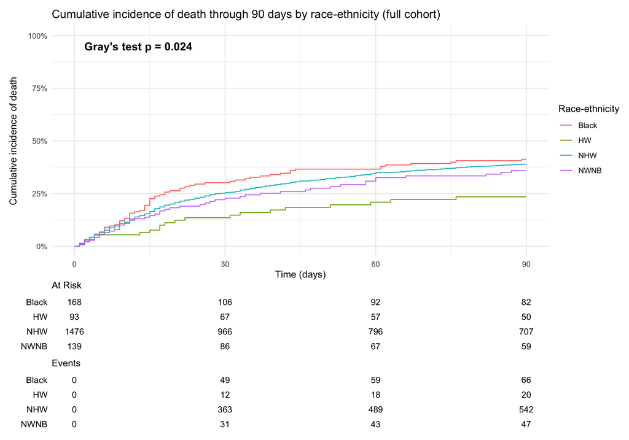

```r
cif_all <- cuminc(Surv(time_90days, status_90days) ~ race_cat_4, data = master)

# Extract Gray's test p-value for the death outcome (outcome code "1")
gray_all <- cif_all$cmprsk$Tests
p_gray_all <- gray_all[rownames(gray_all) == "1", "pv"]
gray_label_all <- paste0("Gray's test p = ", style_pvalue(p_gray_all, digits = 3))

ggcuminc(cif_all, outcome = "1") +
  scale_x_continuous(breaks = seq(0, 90, 30), limits = c(0, 90)) +
  scale_y_continuous(labels = scales::percent, limits = c(0, 1)) +
  labs(
    x = "Time (days)",
    y = "Cumulative incidence of death",
    title = "Cumulative incidence of death through 90 days by race-ethnicity (full cohort)",
    color = "Race-ethnicity"
  ) +
  annotate("text", x = 2, y = 0.95, label = gray_label_all,
           hjust = 0, size = 4.5, fontface = "bold") +
  theme_minimal() +
  add_risktable()
```

## Figure 3: Cumulative Incidence of Death — HRS-AKI Sub-cohort

Unadjusted CIF of death through 90 days by race-ethnicity among patients with HRS-AKI. Overall p-value from Gray’s test across all four groups.

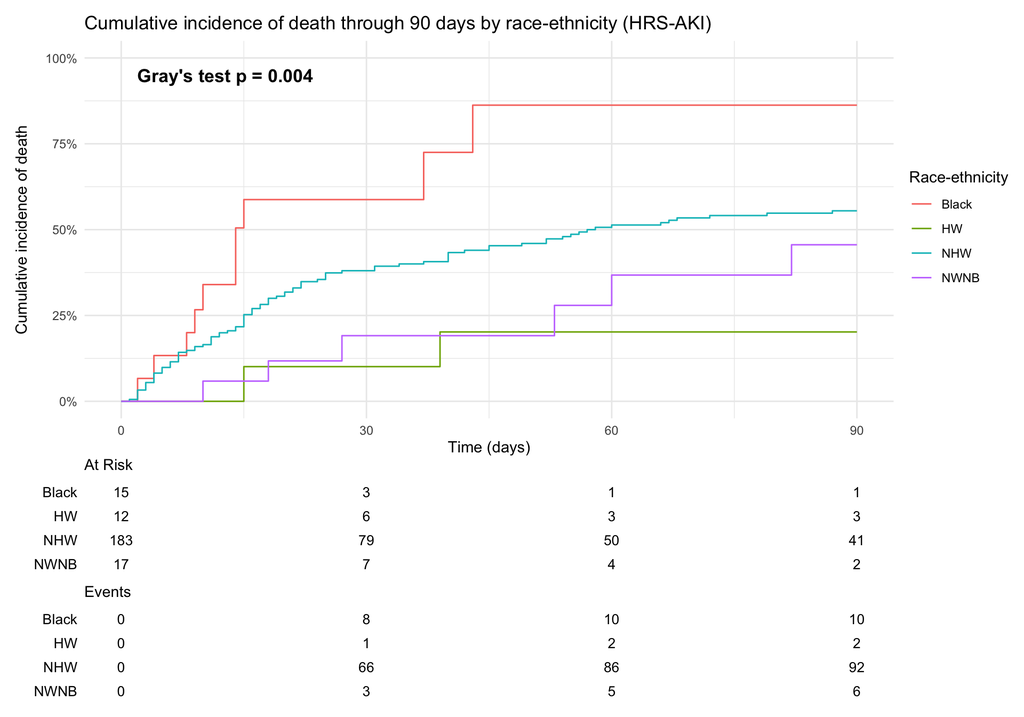

```r
cif_hrs <- cuminc(Surv(time_90days, status_90days) ~ race_cat_4, data = master_hrs)

gray_hrs <- cif_hrs$cmprsk$Tests
p_gray_hrs <- gray_hrs[rownames(gray_hrs) == "1", "pv"]
gray_label_hrs <- paste0("Gray's test p = ", style_pvalue(p_gray_hrs, digits = 3))

ggcuminc(cif_hrs, outcome = "1") +
  scale_x_continuous(breaks = seq(0, 90, 30), limits = c(0, 90)) +
  scale_y_continuous(labels = scales::percent, limits = c(0, 1)) +
  labs(
    x = "Time (days)",
    y = "Cumulative incidence of death",
    title = "Cumulative incidence of death through 90 days by race-ethnicity (HRS-AKI)",
    color = "Race-ethnicity"
  ) +
  annotate("text", x = 2, y = 0.95, label = gray_label_hrs,
           hjust = 0, size = 4.5, fontface = "bold") +
  theme_minimal() +
  add_risktable()
```

## Fine & Gray Model — Race × Liver Transplant Listed Interaction

Fine & Gray competing-risk regression with **death as the main outcome** (liver transplantation as the competing event). Unadjusted model testing `race_cat_4 × liver_transplant_listed` interaction only — no other covariates.

```r
library(cmprsk)

master_int <- master %>%
  filter(!is.na(liver_transplant_listed)) %>%
  mutate(
    lt_listed = factor(liver_transplant_listed,
                       levels = c(0, 1),
                       labels = c("Not listed", "Listed")),
    status_num = as.numeric(as.character(status_90days))
  )

x_int <- model.matrix(~ race_cat_4 * lt_listed, data = master_int)[, -1]

fg_int <- cmprsk::crr(
  ftime = master_int$time_90days,
  fstatus = master_int$status_num,
  cov1 = x_int,
  failcode = 1, cencode = 0
)
```

### Sub-hazard ratios

```r
s <- summary(fg_int)
coef_tbl <- as.data.frame(s$conf.int)
coef_tbl$Variable <- rownames(coef_tbl)
pvals <- 2 * (1 - pnorm(abs(s$coef[, "z"])))
coef_tbl$p <- pvals[match(coef_tbl$Variable, names(pvals))]

coef_tbl %>%
  transmute(
    Variable,
    sHR = sprintf("%.2f", `exp(coef)`),
    `95% CI` = sprintf("%.2f, %.2f", `2.5%`, `97.5%`),
    p = style_pvalue(p, digits = 3)
  ) %>%
  kable(caption = "Fine & Gray: race × LT-listed interaction (unadjusted, death as main outcome, liver transplant as competing event)")
```

Fine & Gray: race × LT-listed interaction (unadjusted, death as main outcome, liver transplant as competing event)

|  | Variable | sHR | 95% CI | p |
| --- | --- | --- | --- | --- |
| race_cat_4Black | race_cat_4Black | 1.00 | 0.76, 1.30 | 0.988 |
| race_cat_4HW | race_cat_4HW | 0.52 | 0.32, 0.85 | 0.009 |
| race_cat_4NWNB | race_cat_4NWNB | 1.04 | 0.77, 1.41 | 0.794 |
| lt_listedListed | lt_listedListed | 0.34 | 0.24, 0.46 | <0.001 |
| race_cat_4Black:lt_listedListed | race_cat_4Black:lt_listedListed | 1.93 | 0.65, 5.68 | 0.234 |
| race_cat_4HW:lt_listedListed | race_cat_4HW:lt_listedListed | 1.72 | 0.51, 5.87 | 0.384 |
| race_cat_4NWNB:lt_listedListed | race_cat_4NWNB:lt_listedListed | 0.46 | 0.14, 1.50 | 0.200 |

### Wald test for the interaction block

```r
int_terms <- grep(":", colnames(x_int), value = TRUE)
idx <- which(colnames(x_int) %in% int_terms)

b <- fg_int$coef[idx]
V <- fg_int$var[idx, idx, drop = FALSE]
wald <- as.numeric(t(b) %*% solve(V) %*% b)
df_wald <- length(b)
p_wald <- pchisq(wald, df = df_wald, lower.tail = FALSE)

tibble(
  Test = "Wald test for race_cat_4 × lt_listed interaction",
  `Chi-sq` = sprintf("%.3f", wald),
  df = df_wald,
  `p-value` = style_pvalue(p_wald, digits = 3)
) %>% kable()
```

| Test | Chi-sq | df | p-value |
| --- | --- | --- | --- |
| Wald test for race_cat_4 × lt_listed interaction | 4.077 | 3 | 0.253 |

### Race sub-hazard ratios stratified by LT-listed status

```r
fg_by_lt <- lapply(levels(master_int$lt_listed), function(lvl) {
  dat <- master_int %>% filter(lt_listed == lvl)
  x <- model.matrix(~ race_cat_4, data = dat)[, -1, drop = FALSE]
  x <- x[, apply(x, 2, function(col) length(unique(col)) > 1), drop = FALSE]
  fit <- try(cmprsk::crr(
    ftime = dat$time_90days,
    fstatus = as.numeric(as.character(dat$status_90days)),
    cov1 = x,
    failcode = 1, cencode = 0
  ), silent = TRUE)
  if (inherits(fit, "try-error")) return(NULL)
  s <- summary(fit)
  out <- as.data.frame(s$conf.int)
  out$Variable <- rownames(out)
  out$p <- 2 * (1 - pnorm(abs(s$coef[, "z"])))[match(out$Variable, rownames(s$coef))]
  out$Stratum <- lvl
  out
})

bind_rows(fg_by_lt) %>%
  transmute(
    Stratum, Variable,
    sHR = sprintf("%.2f", `exp(coef)`),
    `95% CI` = sprintf("%.2f, %.2f", `2.5%`, `97.5%`),
    p = style_pvalue(p, digits = 3)
  ) %>%
  kable(caption = "Unadjusted race sub-hazard ratios stratified by listing for liver transplant")
```

Unadjusted race sub-hazard ratios stratified by listing for liver transplant

|  | Stratum | Variable | sHR | 95% CI | p |
| --- | --- | --- | --- | --- | --- |
| race_cat_4Black…1 | Not listed | race_cat_4Black | 1.00 | 0.76, 1.30 | 0.990 |
| race_cat_4HW…2 | Not listed | race_cat_4HW | 0.52 | 0.32, 0.85 | 0.009 |
| race_cat_4NWNB…3 | Not listed | race_cat_4NWNB | 1.04 | 0.77, 1.41 | 0.796 |
| race_cat_4Black…4 | Listed | race_cat_4Black | 1.97 | 0.68, 5.71 | 0.213 |
| race_cat_4HW…5 | Listed | race_cat_4HW | 0.90 | 0.29, 2.78 | 0.854 |
| race_cat_4NWNB…6 | Listed | race_cat_4NWNB | 0.48 | 0.15, 1.49 | 0.203 |

## Mediation Analysis — LT-Listing as Mediator (Logistic Regression)

**Question:** How much of the association between Black race (vs. non-Black) and 90-day mortality is mediated through listing for liver transplant?

**Causal model:**

```
Black race  ──(direct, NDE)──────▶  Death by day 90
     │                                      ▲
     └──▶  LT listed  ──(indirect, NIE)─────┘
```

**Method:** `CMAverse::cmest()` regression-based estimator with exposure–mediator interaction (Valeri-VanderWeele). Outcome = 90-day mortality (binary: 1 = died by day 90, 0 = alive — includes those who received liver transplant and were alive at day 90); Exposure = Black (1) vs. non-Black (0); Mediator = `liver_transplant_listed` (binary). Both mediator and outcome modeled with logistic regression. Confounders adjusted: age, MELD 3.0, etiology, HCC, diabetes, CAD, CKD, HTN, site. 95% CIs via 500 bootstrap replicates. Effects reported on the **odds-ratio scale**.

```r
library(CMAverse)

med_confounders <- c("age_admission", "meld_3", "etiology_cirrhosis",
                     "hcc_admission", "diabetes", "cad", "ckd", "htn", "site")

make_med_dat <- function(d) {
  num01 <- function(x) as.numeric(as.character(x))
  out <- d %>%
    filter(!is.na(liver_transplant_listed)) %>%
    mutate(
      black         = as.numeric(race_cat_4 == "Black"),
      lt_listed     = num01(liver_transplant_listed),
      # Binary 90-day mortality: 1 = died by day 90, 0 = alive (incl. those who got LT and survived to 90d)
      death_90      = as.numeric(num01(status_90days) == 1),
      age_admission = as.numeric(age_admission),
      meld_3        = as.numeric(meld_3),
      hcc_admission = num01(hcc_admission),
      diabetes      = num01(diabetes),
      cad           = num01(cad),
      ckd           = num01(ckd),
      htn           = num01(htn),
      etiology_cirrhosis = factor(as.character(etiology_cirrhosis)),
      site          = factor(as.character(site))
    ) %>%
    select(all_of(c("black", "lt_listed", "death_90", med_confounders))) %>%
    tidyr::drop_na() %>%
    droplevels()
  as.data.frame(out)
}

run_mediation <- function(dat, label) {
  set.seed(42)
  fit <- cmest(
    data       = dat,
    model      = "rb",
    outcome    = "death_90",
    exposure   = "black",
    mediator   = "lt_listed",
    basec      = med_confounders,
    EMint      = TRUE,
    mreg       = list("logistic"),
    yreg       = "logistic",
    astar      = 0,
    a          = 1,
    mval       = list(0),
    estimation = "imputation",
    inference  = "bootstrap",
    nboot      = 500,
    multimp    = FALSE
  )
  list(fit = fit, label = label, n = nrow(dat))
}

format_cmest <- function(res) {
  fit <- res$fit
  effects <- c("Rcde", "Rpnde", "Rtnde", "Rpnie", "Rtnie", "Rte", "pm")
  est <- fit$effect.pe[effects]
  cil <- fit$effect.ci.low[effects]
  ciu <- fit$effect.ci.high[effects]
  pv  <- fit$effect.pval[effects]
  tibble(
    Effect = effects,
    Meaning = c(
      "Controlled direct effect (fixed M = 0)",
      "Pure natural direct effect (not through LT-listing)",
      "Total natural direct effect",
      "Pure natural indirect effect (through LT-listing)",
      "Total natural indirect effect (through LT-listing)",
      "Total effect",
      "Proportion mediated"
    ),
    `OR (or ratio)` = sprintf("%.3f", est),
    `95% CI` = sprintf("%.3f, %.3f", cil, ciu),
    p = style_pvalue(pv, digits = 3)
  )
}
```

### Full cohort

```r
med_full_dat <- make_med_dat(master)
invisible(capture.output({
  res_full <- run_mediation(med_full_dat, "Full cohort")
}, type = c("output", "message")))
```

```r
kable(format_cmest(res_full),
      caption = paste0("Logistic-regression mediation decomposition -- full cohort (N = ",
                       res_full$n,
                       "). Effects on the odds-ratio scale. pm is proportion of the total effect mediated through LT-listing."))
```

Logistic-regression mediation decomposition – full cohort (N = 1874). Effects on the odds-ratio scale. pm is proportion of the total effect mediated through LT-listing.

| Effect | Meaning | OR (or ratio) | 95% CI | p |
| --- | --- | --- | --- | --- |
| Rcde | Controlled direct effect (fixed M = 0) | 1.024 | 0.729, 1.385 | 0.928 |
| Rpnde | Pure natural direct effect (not through LT-listing) | 1.081 | 0.761, 1.434 | 0.688 |
| Rtnde | Total natural direct effect | 1.056 | 0.742, 1.424 | 0.780 |
| Rpnie | Pure natural indirect effect (through LT-listing) | 1.086 | 1.005, 1.144 | 0.032 |
| Rtnie | Total natural indirect effect (through LT-listing) | 1.061 | 0.989, 1.143 | 0.104 |
| Rte | Total effect | 1.147 | 0.804, 1.510 | 0.492 |
| pm | Proportion mediated | 0.450 | -2.314, 4.694 | 0.508 |

### HRS-AKI sub-cohort

```r
med_hrs_dat <- make_med_dat(master_hrs)
invisible(capture.output({
  res_hrs <- run_mediation(med_hrs_dat, "HRS-AKI")
}, type = c("output", "message")))
```

```r
kable(format_cmest(res_hrs),
      caption = paste0("Logistic-regression mediation decomposition -- HRS-AKI sub-cohort (N = ",
                       res_hrs$n,
                       "). **Caution:** very wide bootstrap CIs reflect the small sample and low event count in this subgroup."))
```

Logistic-regression mediation decomposition – HRS-AKI sub-cohort (N = 227). **Caution:** very wide bootstrap CIs reflect the small sample and low event count in this subgroup.

| Effect | Meaning | OR (or ratio) | 95% CI | p |
| --- | --- | --- | --- | --- |
| Rcde | Controlled direct effect (fixed M = 0) | 1.577 | 0.541, 6.736 | 0.388 |
| Rpnde | Pure natural direct effect (not through LT-listing) | 1.588 | 0.646, 8.108 | 0.332 |
| Rtnde | Total natural direct effect | 1.589 | 0.639, 7.874 | 0.352 |
| Rpnie | Pure natural indirect effect (through LT-listing) | 0.994 | 0.581, 1.982 | 0.748 |
| Rtnie | Total natural indirect effect (through LT-listing) | 0.994 | 0.577, 2.349 | 0.904 |
| Rte | Total effect | 1.579 | 0.558, 8.766 | 0.288 |
| pm | Proportion mediated | -0.016 | -3.599, 4.130 | 0.936 |

**How to read the table:**

- **Rcde (controlled direct effect OR)** — effect of race on 90-day mortality with LT-listing held fixed at 0 (not listed).
- **Rpnde (pure natural direct)** — portion NOT through LT-listing, on the OR scale.
- **Rtnde (total natural direct)** — includes mediated interaction.
- **Rpnie / Rtnie (natural indirect)** — portion THROUGH LT-listing.
- **Rte (total effect OR)** — total OR of 90-day death, Black vs. non-Black.
- **pm (proportion mediated)** — fraction of the total effect explained by LT-listing. Values outside [0, 1] indicate the indirect effect opposes the total, or the total effect is near null.